# INN Hotels Project

## Context

A significant number of hotel bookings are called-off due to cancellations or no-shows. The typical reasons for cancellations include change of plans, scheduling conflicts, etc. This is often made easier by the option to do so free of charge or preferably at a low cost which is beneficial to hotel guests but it is a less desirable and possibly revenue-diminishing factor for hotels to deal with. Such losses are particularly high on last-minute cancellations.

The new technologies involving online booking channels have dramatically changed customers’ booking possibilities and behavior. This adds a further dimension to the challenge of how hotels handle cancellations, which are no longer limited to traditional booking and guest characteristics.

The cancellation of bookings impact a hotel on various fronts:

- Loss of resources (revenue) when the hotel cannot resell the room.
- Additional costs of distribution channels by increasing commissions or paying for publicity to help sell these rooms.
- Lowering prices last minute, so the hotel can resell a room, resulting in reducing the profit margin.
- Human resources to make arrangements for the guests.

## Objective

The increasing number of cancellations calls for a Machine Learning based solution that can help in predicting which booking is likely to be canceled. INN Hotels Group has a chain of hotels in Portugal, they are facing problems with the high number of booking cancellations and have reached out to your firm for data-driven solutions. As a data scientist, I have to analyze the data provided to find which factors have a high influence on booking cancellations, build a predictive model that can predict which booking is going to be canceled in advance, and help in formulating profitable policies for cancellations and refunds.

## Data Description

The data contains the different attributes of customers' booking details. The detailed data dictionary is given below.

**Data Dictionary**

- Booking_ID: unique identifier of each booking
- no_of_adults: Number of adults
- no_of_children: Number of Children
- no_of_weekend_nights: Number of weekend nights (Saturday or Sunday) the guest stayed or booked to stay at the hotel
- no_of_week_nights: Number of week nights (Monday to Friday) the guest stayed or booked to stay at the hotel
- type_of_meal_plan: Type of meal plan booked by the customer:
  - Not Selected – No meal plan selected
  - Meal Plan 1 – Breakfast
  - Meal Plan 2 – Half board (breakfast and one other meal)
  - Meal Plan 3 – Full board (breakfast, lunch, and dinner)
- required_car_parking_space: Does the customer require a car parking space? (0 - No, 1- Yes)
- room_type_reserved: Type of room reserved by the customer. The values are ciphered (encoded) by INN Hotels.
- lead_time: Number of days between the date of booking and the arrival date
- arrival_year: Year of arrival date
- arrival_month: Month of arrival date
- arrival_date: Date of the month
- market_segment_type: Market segment designation.
- repeated_guest: Is the customer a repeated guest? (0 - No, 1- Yes)
- no_of_previous_cancellations: Number of previous bookings that were canceled by the customer prior to the current booking
- no_of_previous_bookings_not_canceled: Number of previous bookings not canceled by the customer prior to the current booking
- avg_price_per_room: Average price per day of the reservation; prices of the rooms are dynamic. (in euros)
- no_of_special_requests: Total number of special requests made by the customer (e.g. high floor, view from the room, etc)
- booking_status: Flag indicating if the booking was canceled or not.

## Importing necessary libraries and data

```python
# Installing the libraries with the specified version.
#!pip install pandas==1.5.3 numpy==1.25.2 matplotlib==3.7.1 seaborn==0.13.1 scikit-learn==1.2.2 statsmodels==0.14.1 -q --user
```

**Note**: *After running the above cell, kindly restart the notebook kernel and run all cells sequentially from the start again.*

```python
# Libraries to help with reading and manipulating data
import pandas as pd
import numpy as np

# libaries to help with data visualization
import matplotlib.pyplot as plt
import seaborn as sns

# Removes the limit for the number of displayed columns
pd.set_option("display.max_columns", None)
# Sets the limit for the number of displayed rows
pd.set_option("display.max_rows", 200)
# setting the precision of floating numbers to 5 decimal points
pd.set_option("display.float_format", lambda x: "%.5f" % x)

# Library to split data
from sklearn.model_selection import train_test_split

# To build model for prediction
import statsmodels.stats.api as sms
from statsmodels.stats.outliers_influence import variance_inflation_factor
import statsmodels.api as sm
from statsmodels.tools.tools import add_constant
from sklearn.tree import DecisionTreeClassifier
from sklearn import tree

# To tune different models
from sklearn.model_selection import GridSearchCV


# To get diferent metric scores
from sklearn.metrics import (
    f1_score,
    accuracy_score,
    recall_score,
    precision_score,
    confusion_matrix,
    roc_auc_score,
    precision_recall_curve,
    roc_curve,
    make_scorer,
)

import warnings
warnings.filterwarnings("ignore")

from statsmodels.tools.sm_exceptions import ConvergenceWarning
warnings.simplefilter("ignore", ConvergenceWarning)
```

## Import Dataset

```python
from google.colab import drive
drive.mount('/content/drive')
```

```python
# loading data
data = pd.read_csv('/content/drive/MyDrive/content/INNHotelsGroup.csv')
```

## Data Overview

- Observations
- Sanity checks

#### Observations

**Displaying the first few rows of the dataset**

```python
data.head()
```

|  | Booking_ID | no_of_adults | no_of_children | no_of_weekend_nights | no_of_week_nights | type_of_meal_plan | required_car_parking_space | room_type_reserved | lead_time | arrival_year | arrival_month | arrival_date | market_segment_type | repeated_guest | no_of_previous_cancellations | no_of_previous_bookings_not_canceled | avg_price_per_room | no_of_special_requests | booking_status |
| --- | --- | --- | --- | --- | --- | --- | --- | --- | --- | --- | --- | --- | --- | --- | --- | --- | --- | --- | --- |
| 0 | INN00001 | 2 | 0 | 1 | 2 | Meal Plan 1 | 0 | Room_Type 1 | 224 | 2017 | 10 | 2 | Offline | 0 | 0 | 0 | 65.00000 | 0 | Not_Canceled |
| 1 | INN00002 | 2 | 0 | 2 | 3 | Not Selected | 0 | Room_Type 1 | 5 | 2018 | 11 | 6 | Online | 0 | 0 | 0 | 106.68000 | 1 | Not_Canceled |
| 2 | INN00003 | 1 | 0 | 2 | 1 | Meal Plan 1 | 0 | Room_Type 1 | 1 | 2018 | 2 | 28 | Online | 0 | 0 | 0 | 60.00000 | 0 | Canceled |
| 3 | INN00004 | 2 | 0 | 0 | 2 | Meal Plan 1 | 0 | Room_Type 1 | 211 | 2018 | 5 | 20 | Online | 0 | 0 | 0 | 100.00000 | 0 | Canceled |
| 4 | INN00005 | 2 | 0 | 1 | 1 | Not Selected | 0 | Room_Type 1 | 48 | 2018 | 4 | 11 | Online | 0 | 0 | 0 | 94.50000 | 0 | Canceled |

**Displaying the last few rows of the dataset**

```python
data.tail()
```

|  | Booking_ID | no_of_adults | no_of_children | no_of_weekend_nights | no_of_week_nights | type_of_meal_plan | required_car_parking_space | room_type_reserved | lead_time | arrival_year | arrival_month | arrival_date | market_segment_type | repeated_guest | no_of_previous_cancellations | no_of_previous_bookings_not_canceled | avg_price_per_room | no_of_special_requests | booking_status |
| --- | --- | --- | --- | --- | --- | --- | --- | --- | --- | --- | --- | --- | --- | --- | --- | --- | --- | --- | --- |
| 36270 | INN36271 | 3 | 0 | 2 | 6 | Meal Plan 1 | 0 | Room_Type 4 | 85 | 2018 | 8 | 3 | Online | 0 | 0 | 0 | 167.80000 | 1 | Not_Canceled |
| 36271 | INN36272 | 2 | 0 | 1 | 3 | Meal Plan 1 | 0 | Room_Type 1 | 228 | 2018 | 10 | 17 | Online | 0 | 0 | 0 | 90.95000 | 2 | Canceled |
| 36272 | INN36273 | 2 | 0 | 2 | 6 | Meal Plan 1 | 0 | Room_Type 1 | 148 | 2018 | 7 | 1 | Online | 0 | 0 | 0 | 98.39000 | 2 | Not_Canceled |
| 36273 | INN36274 | 2 | 0 | 0 | 3 | Not Selected | 0 | Room_Type 1 | 63 | 2018 | 4 | 21 | Online | 0 | 0 | 0 | 94.50000 | 0 | Canceled |
| 36274 | INN36275 | 2 | 0 | 1 | 2 | Meal Plan 1 | 0 | Room_Type 1 | 207 | 2018 | 12 | 30 | Offline | 0 | 0 | 0 | 161.67000 | 0 | Not_Canceled |

**Shape of the data**

```python
data.shape
```

```
(36275, 19)
```

**Observations**

Total Rows in the DS: 36275

Total Columns in the DS: 19

**Checking type of columns**

```python
data.info()
```

```
<class 'pandas.core.frame.DataFrame'>
RangeIndex: 36275 entries, 0 to 36274
Data columns (total 19 columns):
 #   Column                                Non-Null Count  Dtype
---  ------                                --------------  -----
 0   Booking_ID                            36275 non-null  object
 1   no_of_adults                          36275 non-null  int64
 2   no_of_children                        36275 non-null  int64
 3   no_of_weekend_nights                  36275 non-null  int64
 4   no_of_week_nights                     36275 non-null  int64
 5   type_of_meal_plan                     36275 non-null  object
 6   required_car_parking_space            36275 non-null  int64
 7   room_type_reserved                    36275 non-null  object
 8   lead_time                             36275 non-null  int64
 9   arrival_year                          36275 non-null  int64
 10  arrival_month                         36275 non-null  int64
 11  arrival_date                          36275 non-null  int64
 12  market_segment_type                   36275 non-null  object
 13  repeated_guest                        36275 non-null  int64
 14  no_of_previous_cancellations          36275 non-null  int64
 15  no_of_previous_bookings_not_canceled  36275 non-null  int64
 16  avg_price_per_room                    36275 non-null  float64
 17  no_of_special_requests                36275 non-null  int64
 18  booking_status                        36275 non-null  object
dtypes: float64(1), int64(13), object(5)
memory usage: 5.3+ MB
```

**Observations**:

**Dropping Booking_ID since it does not produce any value**

```python
data = data.drop("Booking_ID", axis=1)
```

## Exploratory Data Analysis (EDA)

- EDA is an important part of any project involving data.
- It is important to investigate and understand the data better before building a model with it.
- A few questions have been mentioned below which will help you approach the analysis in the right manner and generate insights from the data.
- A thorough analysis of the data, in addition to the questions mentioned below, should be done.

**Leading Questions**:

1. What are the busiest months in the hotel?
2. Which market segment do most of the guests come from?
3. Hotel rates are dynamic and change according to demand and customer demographics. What are the differences in room prices in different market segments?
4. What percentage of bookings are canceled?
5. Repeating guests are the guests who stay in the hotel often and are important to brand equity. What percentage of repeating guests cancel?
6. Many guests have special requirements when booking a hotel room. Do these requirements affect booking cancellation?

**Statistical summary of the dataset**

```python
data.describe(include='all').T
```

|  | count | unique | top | freq | mean | std | min | 25% | 50% | 75% | max |
| --- | --- | --- | --- | --- | --- | --- | --- | --- | --- | --- | --- |
| no_of_adults | 36275.00000 | NaN | NaN | NaN | 1.84496 | 0.51871 | 0.00000 | 2.00000 | 2.00000 | 2.00000 | 4.00000 |
| no_of_children | 36275.00000 | NaN | NaN | NaN | 0.10528 | 0.40265 | 0.00000 | 0.00000 | 0.00000 | 0.00000 | 10.00000 |
| no_of_weekend_nights | 36275.00000 | NaN | NaN | NaN | 0.81072 | 0.87064 | 0.00000 | 0.00000 | 1.00000 | 2.00000 | 7.00000 |
| no_of_week_nights | 36275.00000 | NaN | NaN | NaN | 2.20430 | 1.41090 | 0.00000 | 1.00000 | 2.00000 | 3.00000 | 17.00000 |
| type_of_meal_plan | 36275 | 4 | Meal Plan 1 | 27835 | NaN | NaN | NaN | NaN | NaN | NaN | NaN |
| required_car_parking_space | 36275.00000 | NaN | NaN | NaN | 0.03099 | 0.17328 | 0.00000 | 0.00000 | 0.00000 | 0.00000 | 1.00000 |
| room_type_reserved | 36275 | 7 | Room_Type 1 | 28130 | NaN | NaN | NaN | NaN | NaN | NaN | NaN |
| lead_time | 36275.00000 | NaN | NaN | NaN | 85.23256 | 85.93082 | 0.00000 | 17.00000 | 57.00000 | 126.00000 | 443.00000 |
| arrival_year | 36275.00000 | NaN | NaN | NaN | 2017.82043 | 0.38384 | 2017.00000 | 2018.00000 | 2018.00000 | 2018.00000 | 2018.00000 |
| arrival_month | 36275.00000 | NaN | NaN | NaN | 7.42365 | 3.06989 | 1.00000 | 5.00000 | 8.00000 | 10.00000 | 12.00000 |
| arrival_date | 36275.00000 | NaN | NaN | NaN | 15.59700 | 8.74045 | 1.00000 | 8.00000 | 16.00000 | 23.00000 | 31.00000 |
| market_segment_type | 36275 | 5 | Online | 23214 | NaN | NaN | NaN | NaN | NaN | NaN | NaN |
| repeated_guest | 36275.00000 | NaN | NaN | NaN | 0.02564 | 0.15805 | 0.00000 | 0.00000 | 0.00000 | 0.00000 | 1.00000 |
| no_of_previous_cancellations | 36275.00000 | NaN | NaN | NaN | 0.02335 | 0.36833 | 0.00000 | 0.00000 | 0.00000 | 0.00000 | 13.00000 |
| no_of_previous_bookings_not_canceled | 36275.00000 | NaN | NaN | NaN | 0.15341 | 1.75417 | 0.00000 | 0.00000 | 0.00000 | 0.00000 | 58.00000 |
| avg_price_per_room | 36275.00000 | NaN | NaN | NaN | 103.42354 | 35.08942 | 0.00000 | 80.30000 | 99.45000 | 120.00000 | 540.00000 |
| no_of_special_requests | 36275.00000 | NaN | NaN | NaN | 0.61966 | 0.78624 | 0.00000 | 0.00000 | 0.00000 | 1.00000 | 5.00000 |
| booking_status | 36275 | 2 | Not_Canceled | 24390 | NaN | NaN | NaN | NaN | NaN | NaN | NaN |

**Observations:**

## Data Preprocessing

- Missing value treatment (if needed)
- Feature engineering (if needed)
- Outlier detection and treatment (if needed)
- Preparing data for modeling
- Any other preprocessing steps (if needed)

**Checking for null values**

```python
data.isnull().sum()
```

|  | 0 |
| --- | --- |
| no_of_adults | 0 |
| no_of_children | 0 |
| no_of_weekend_nights | 0 |
| no_of_week_nights | 0 |
| type_of_meal_plan | 0 |
| required_car_parking_space | 0 |
| room_type_reserved | 0 |
| lead_time | 0 |
| arrival_year | 0 |
| arrival_month | 0 |
| arrival_date | 0 |
| market_segment_type | 0 |
| repeated_guest | 0 |
| no_of_previous_cancellations | 0 |
| no_of_previous_bookings_not_canceled | 0 |
| avg_price_per_room | 0 |
| no_of_special_requests | 0 |
| booking_status | 0 |

**dtype:** int64

Observations: There are **no** missing values in the data

```python
# creating a copy of the data so that original data is not changed.
df = data.copy()
```

## EDA

- It is a good idea to explore the data once again after manipulating it.

#### **`Global Functions`**

```python
def labeled_barplot(data, feature, perc=False, n=None):
    """
    Barplot with percentage at the top

    data: dataframe
    feature: dataframe column
    perc: whether to display percentages instead of count (default is False)
    n: displays the top n category levels (default is None, i.e., display all levels)
    """

    total = len(data[feature])  # length of the column
    count = data[feature].nunique()
    if n is None:
        plt.figure(figsize=(count + 2, 6))
    else:
        plt.figure(figsize=(n + 2, 6))

    plt.xticks(rotation=90, fontsize=15)
    ax = sns.countplot(
        data=data,
        x=feature,
        palette="Paired",
        order=data[feature].value_counts().index[:n].sort_values(),
    )

    for p in ax.patches:
        if perc == True:
            label = "{:.1f}%".format(
                100 * p.get_height() / total
            )  # percentage of each class of the category
        else:
            label = p.get_height()  # count of each level of the category

        x = p.get_x() + p.get_width() / 2  # width of the plot
        y = p.get_height()  # height of the plot

        ax.annotate(
            label,
            (x, y),
            ha="center",
            va="center",
            size=12,
            xytext=(0, 5),
            textcoords="offset points",
        )  # annotate the percentage

    plt.show()  # show the plot
```

```python
def stacked_barplot(data, predictor, target):
    """
    Print the category counts and plot a stacked bar chart

    data: dataframe
    predictor: independent variable
    target: target variable
    """
    count = data[predictor].nunique()
    sorter = data[target].value_counts().index[-1]
    tab1 = pd.crosstab(data[predictor], data[target], margins=True).sort_values(
        by=sorter, ascending=False
    )
    print(tab1)
    print("-" * 120)
    tab = pd.crosstab(data[predictor], data[target], normalize="index").sort_values(
        by=sorter, ascending=False
    )
    tab.plot(kind="bar", stacked=True, figsize=(count + 5, 5))
    plt.legend(
        loc="lower left", frameon=False,
    )
    plt.legend(loc="upper left", bbox_to_anchor=(1, 1))
    plt.show()
```

```python
### function to plot distributions wrt target
def distribution_plot_wrt_target(data, predictor, target):

    fig, axs = plt.subplots(2, 2, figsize=(12, 10))

    target_uniq = data[target].unique()

    axs[0, 0].set_title("Distribution of target for target=" + str(target_uniq[0]))
    sns.histplot(
        data=data[data[target] == target_uniq[0]],
        x=predictor,
        kde=True,
        ax=axs[0, 0],
        color="teal",
        stat="density",
    )

    axs[0, 1].set_title("Distribution of target for target=" + str(target_uniq[1]))
    sns.histplot(
        data=data[data[target] == target_uniq[1]],
        x=predictor,
        kde=True,
        ax=axs[0, 1],
        color="orange",
        stat="density",
    )

    axs[1, 0].set_title("Boxplot w.r.t target")
    sns.boxplot(data=data, x=target, y=predictor, ax=axs[1, 0], palette="gist_rainbow")

    axs[1, 1].set_title("Boxplot (without outliers) w.r.t target")
    sns.boxplot(
        data=data,
        x=target,
        y=predictor,
        ax=axs[1, 1],
        showfliers=False,
        palette="gist_rainbow",
    )

    plt.tight_layout()
    plt.show()
```

### UNIVARIATE ANALYSIS

#### **`Distribution of total of adults`**

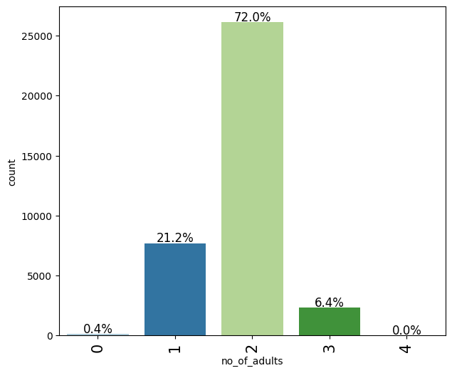

```python
labeled_barplot(df, 'no_of_adults', perc=True, n=None)
```

**Observations:**

- The bast majority of guests per room in the hotel is **2** representing the **72%**
- The second most common total guests per room is **1** with **21%**

#### **`Distribution of total of children`**

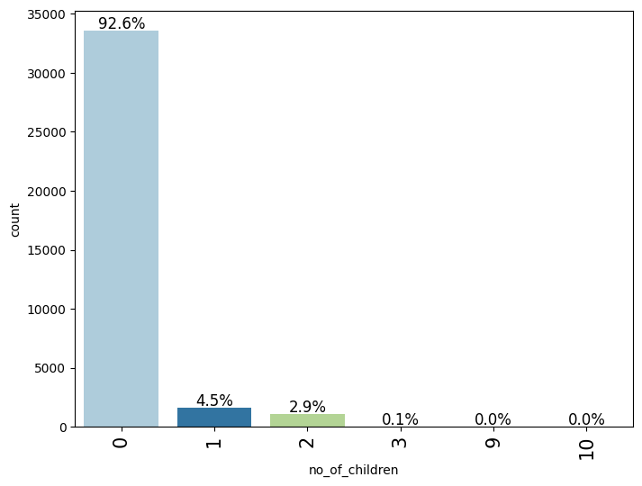

```python
labeled_barplot(df, 'no_of_children', perc=True, n=None)
```

**Observations:**

- The bast majority of guests do not have children representing the **92.6%**

Children with values 9 and 10 seem odd hence grouping all values as 3 for model purposes.

```python
df["no_of_children"] = df["no_of_children"].replace([9, 10], 3)
```

#### **`Distribution of weekend nights`**

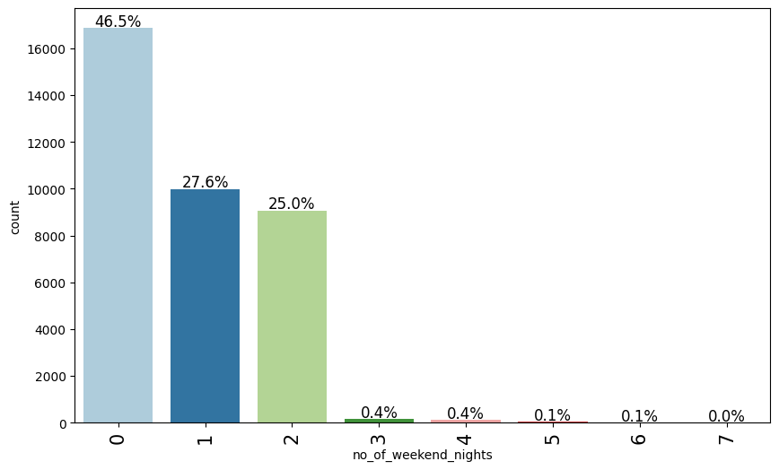

```python
labeled_barplot(df, 'no_of_weekend_nights', perc=True, n=None)
```

**Observations:**

- Majority of guests did not book nights during the weekends with **46.5%**
- The second most common booking option during weekends is guests staying only 1 night with **27.6%** and finally **25%** of total customers stayed 2 nights during the end of the week.

#### **`Distribution of week nights`**

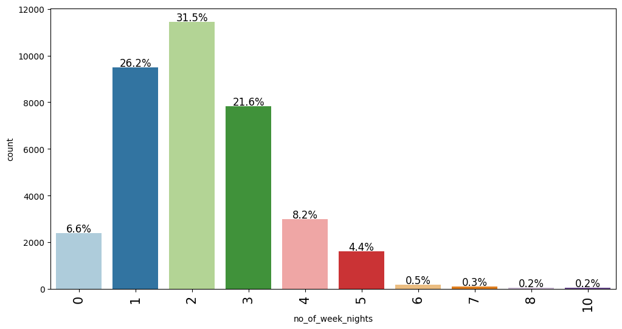

```python
labeled_barplot(df, 'no_of_week_nights', perc=True, n=10)
```

**Observations:**

- Most of guests prefered to book 2 nights in the hotel representing **31.5%**
- The second most common booking option during the week is guests staying only 1 night with **26.2%** and finally **21.6%** of total customers stayed 3 nights during the end of the week.

#### **`Type of meal plan selected`**

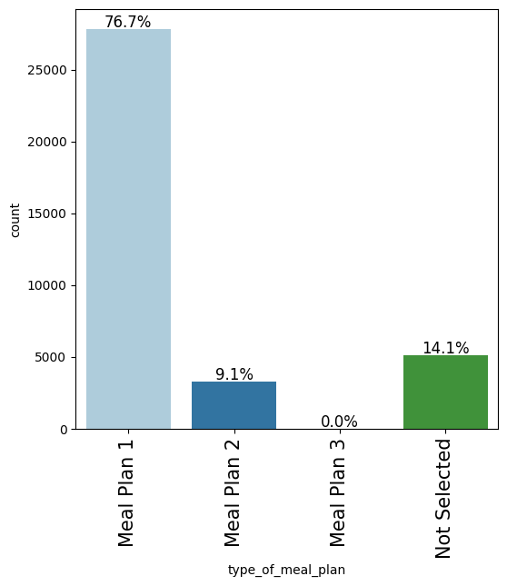

```python
labeled_barplot(df, 'type_of_meal_plan', perc=True, n=None)
```

**Observations:**

- Most of guests prefered to book select the Meal Plan 1 -only breakfast- with **76.7%**
- The second most common meal selection plan is Not having a plan at all with **14.1%** of total customers opting for this option.

#### **`Required parking space`**

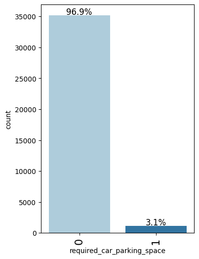

```python
labeled_barplot(df, 'required_car_parking_space', perc=True, n=None)
```

**Observations:**

- The extensive majority of customers do not require a parking space representing a total of **96.9%**

#### **`Room type`**

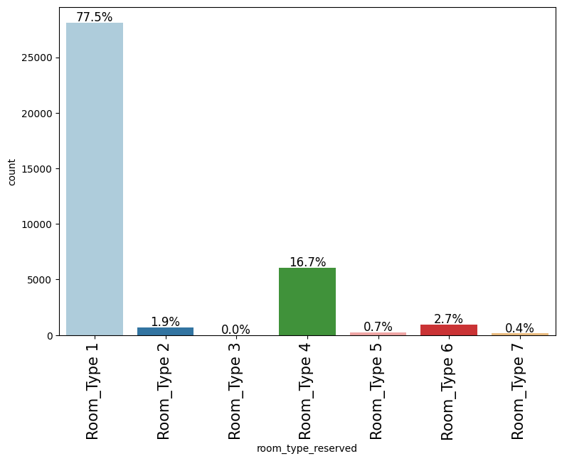

```python
labeled_barplot(df, 'room_type_reserved', perc=True, n=None)
```

**Observations:**

- Most of guests prefered to book a room type 1 **77.5%**
- The second option selected is room type 4 with **16.7%**
- Codification is encoded and only the hotel chain knows the value of the options.

#### **`Lead Time`**

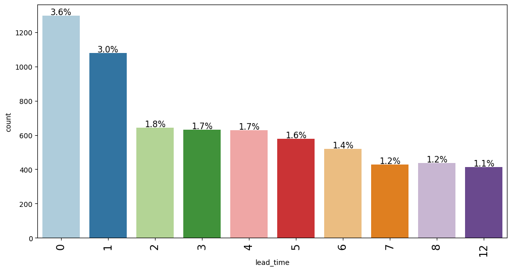

```python
labeled_barplot(df, 'lead_time', perc=True, n=10)
```

**Observations:**

#### **`Arrival year`**

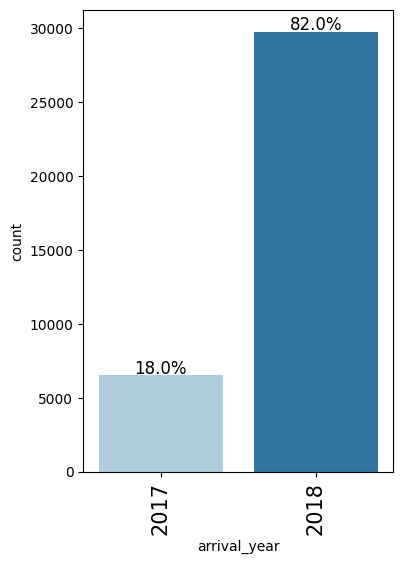

```python
labeled_barplot(df, 'arrival_year', perc=True)
```

**Observations:**

- Data shows that all reservations of the analysis were done in 2018 with a total of **82%** and 2017 representing the remaining **18%**.

#### **`Arrival month`**

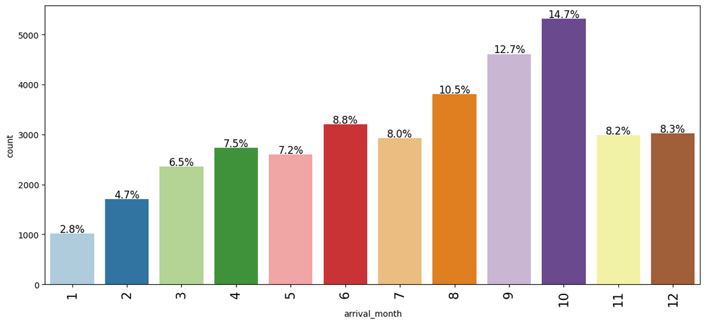

```python
labeled_barplot(df, 'arrival_month', perc=True)
```

**Observations:**

#### **`Arrival date`**

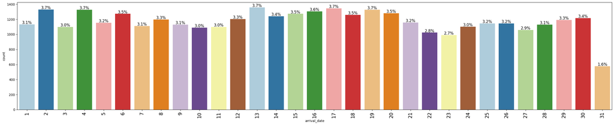

```python
labeled_barplot(df, 'arrival_date', perc=True)
```

**Observations:**

- Arrival day shows almost an evenly distributed selection which reflects no specific preference among customers. The only date worth notice is the 31st of the month which receives really low bookings **(1.6%)**. Owners might investigate and find ways to increase the occupancy around this specific day.

#### **`Market segment type`**

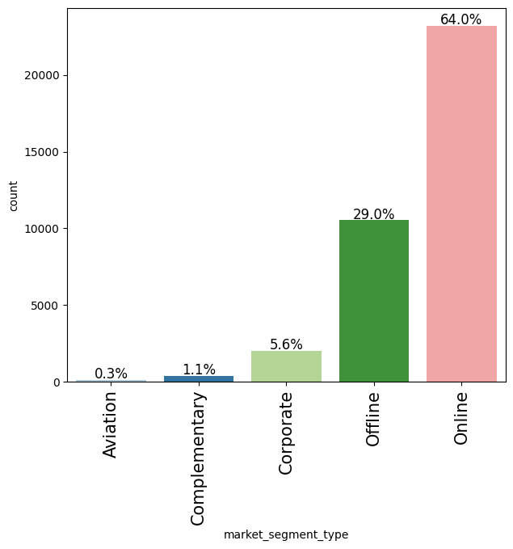

```python
labeled_barplot(df, 'market_segment_type', perc=True)
```

**Observations:**

- The majority of customers select to book the hotel online with **64%** of the total.
- The second most common option is to reserve a room offline (over the counter) with a total of **29%** of the guests selecting this method.

#### **`Repeated guest`**

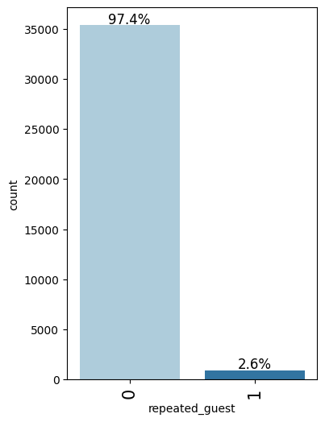

```python
labeled_barplot(df, 'repeated_guest', perc=True)
```

**Observations:**

- The data shows that the hotel receives new customers **97.4%** of the time that is booked and only get **2.6%** of recurrent clients.

#### **`Total of previous cancellations`**

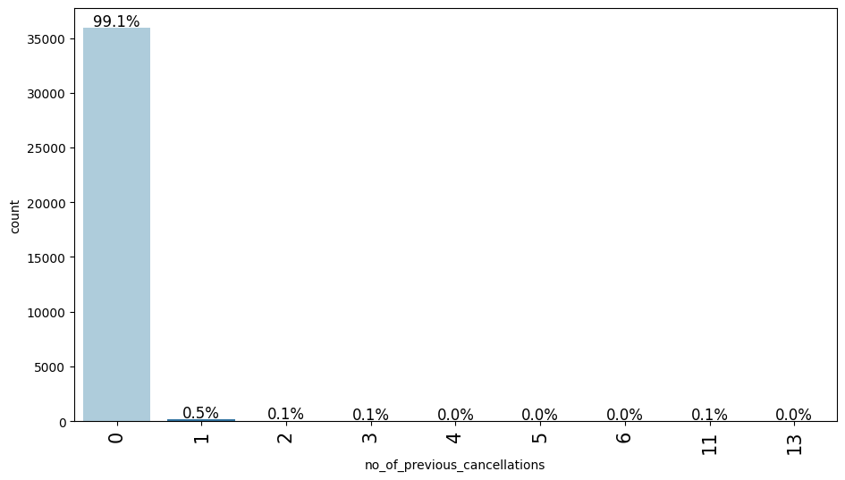

```python
labeled_barplot(df, 'no_of_previous_cancellations', perc=True)
```

**Observations:**

#### **`Total of previous bookings not canceled`**

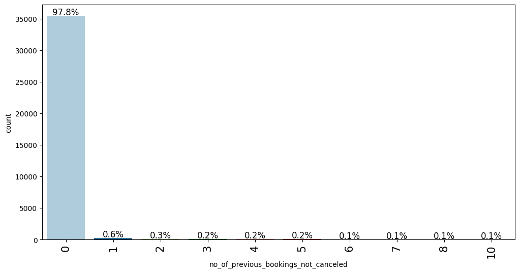

```python
labeled_barplot(df, 'no_of_previous_bookings_not_canceled', perc=True, n=10)
```

**Observations:**

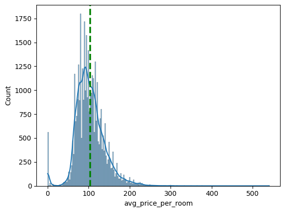

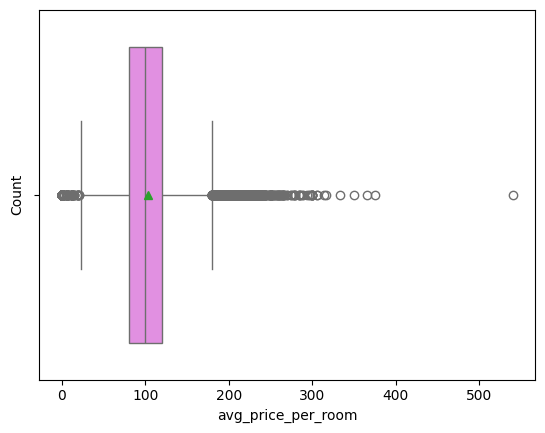

```python
#Histogram
sns.histplot(df, x = 'avg_price_per_room', kde=True);
plt.xlabel('avg_price_per_room');
plt.axvline(x=df.avg_price_per_room.mean(),
            color='green', ls='--',
            lw=2.5)
plt.show()

#Boxplot
sns.boxplot(df, x = 'avg_price_per_room', showmeans=True, color="violet");
plt.xlabel('avg_price_per_room');
plt.ylabel('Count');
plt.show()
```

**Observations:**

```python
len(df[df['avg_price_per_room']==0])
```

```
545
```

There are 545 bookings which price is marked as $0.

```python
#Understanding rooms with cost of $0
df.loc[data["avg_price_per_room"] == 0, "market_segment_type"].value_counts()
```

| market_segment_type | count |
| --- | --- |
| Complementary | 354 |
| Online | 191 |

**dtype:** int64

Majority of rooms with no cost seems to be due to complementary services given by the hotel. No major action to take on these ones.

```python
#Understanding rooms with really high cost to the right of the distribution.
len(df[df['avg_price_per_room'] >= 400])
```

```
1
```

```python
# Assigning the highest value in the boxplot to the values 500 or above to eliminate the single value
# that far to the right that doesn't seem to follow the average.
```

```python
# Calculating the 25th quantile
Q1 = df["avg_price_per_room"].quantile(0.25)

# Calculating the 75th quantile
Q3 = df["avg_price_per_room"].quantile(0.75)

# Calculating IQR
IQR = Q3 - Q1

# Calculating value of upper whisker
Upper_Whisker = Q3 + 1.5 * IQR
Upper_Whisker
```

```
179.55
```

```python
# assigning the outliers the value of upper whisker
df.loc[df["avg_price_per_room"] >= 500, "avg_price_per_room"] = Upper_Whisker
```

#### **`Special requests`**

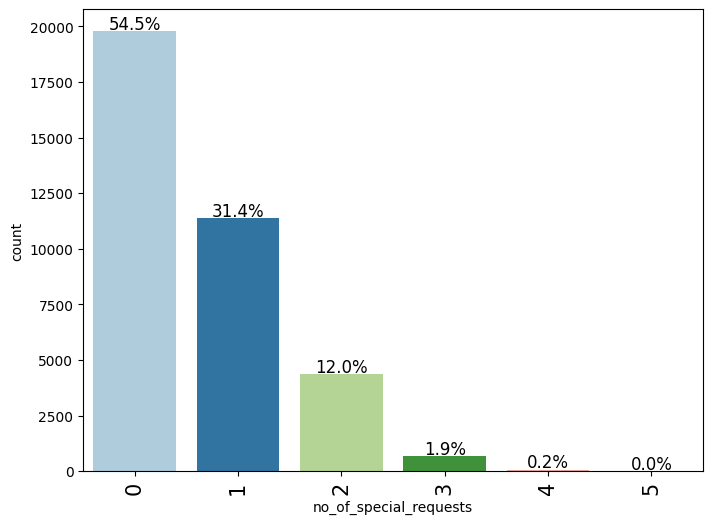

```python
labeled_barplot(df, 'no_of_special_requests', perc=True)
```

**Observations:**

- **More than 50%** of the guests did not request any special accomodation.
- Around **31%** of bookings did have an special request.

#### **`Booking status`**

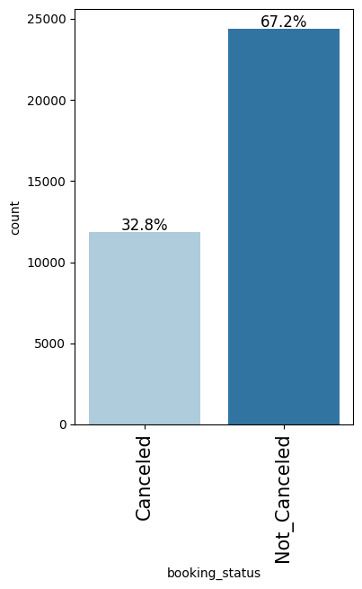

```python
labeled_barplot(df, 'booking_status', perc=True)
```

**Observations:**

- Information shows that around **33%** of booking are being cancelled
- This variable requires analysis and be able to determine of a booking is likely to be cancelled.

Changing value of cancellations from categorical to numerical for better management within the model.

```python
df["booking_status"] = df["booking_status"].replace(['Canceled'], 1)
df["booking_status"] = df["booking_status"].replace(['Not_Canceled'], 0)
```

### BIVARIATE ANALYSIS

#### **`Correlation`**

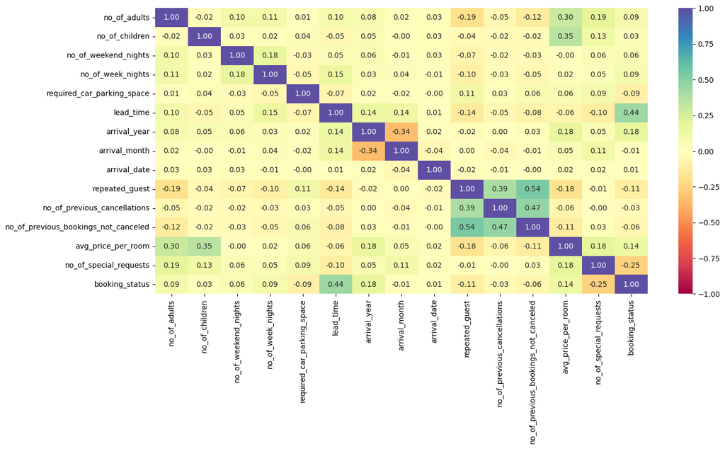

```python
cols_list = df.select_dtypes(include=np.number).columns.tolist()
plt.figure(figsize=(15, 7))
sns.heatmap(
    df[cols_list].corr(), annot=True, vmin=-1, vmax=1, fmt=".2f", cmap="Spectral"
)
plt.show()
```

**Observations**

#### **`Room price by segment`**

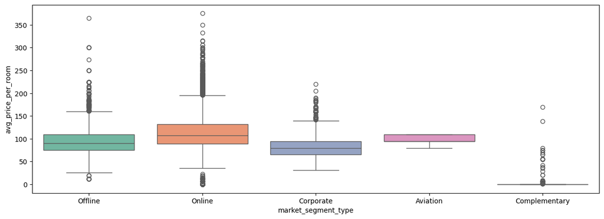

```python
plt.figure(figsize=(15, 5))
sns.boxplot(data=df, x="market_segment_type", y="avg_price_per_room", palette='Set2')
plt.show()
```

**Observations**

- Online booking reflects a higher price range being the most commonly used by users.
- Corporate bookings have a lower cost which could be assumed are special rates given to companies.

#### **`Booking status by segment`**

```
booking_status           0      1    All
market_segment_type
All                  24390  11885  36275
Online               14739   8475  23214
Offline               7375   3153  10528
Corporate             1797    220   2017
Aviation                88     37    125
Complementary          391      0    391
------------------------------------------------------------------------------------------------------------------------
```

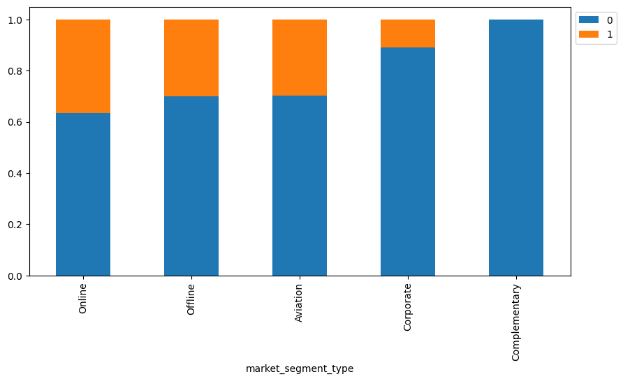

```python
stacked_barplot(df, "market_segment_type", "booking_status")
```

**Observations**

- Online bookings are the most recurrent ones to be canceled
- Complementary bookings have no cancellations.

#### **`Special requests and cancellations`**

```
booking_status              0      1    All
no_of_special_requests
All                     24390  11885  36275
0                       11232   8545  19777
1                        8670   2703  11373
2                        3727    637   4364
3                         675      0    675
4                          78      0     78
5                           8      0      8
------------------------------------------------------------------------------------------------------------------------
```

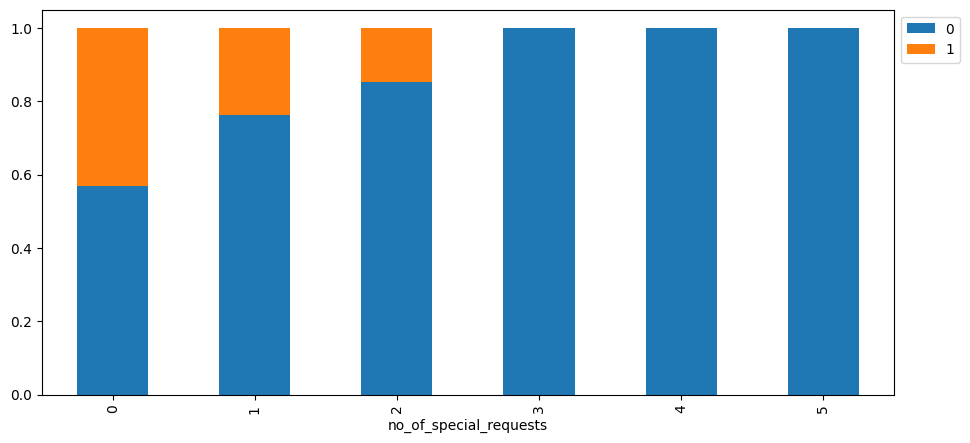

```python
stacked_barplot(df, "no_of_special_requests", "booking_status")
```

**Observations**

#### **`Special requests and room price`**

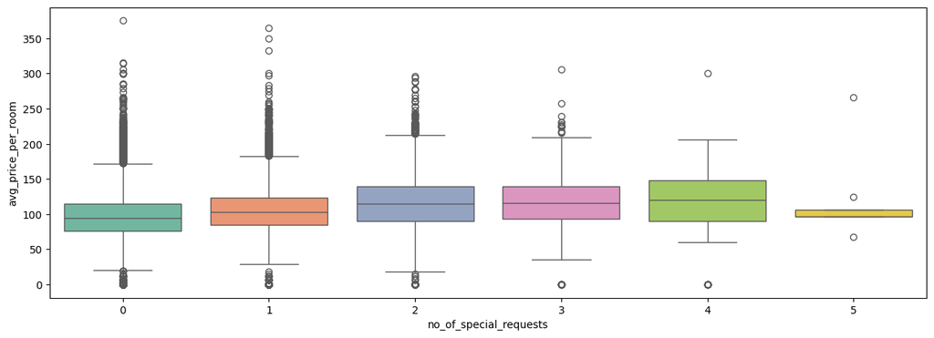

```python
plt.figure(figsize=(15, 5))
sns.boxplot(data=df, x="no_of_special_requests", y="avg_price_per_room", palette='Set2')
plt.show()
```

**Observations**

#### **`Booking status and room price`**

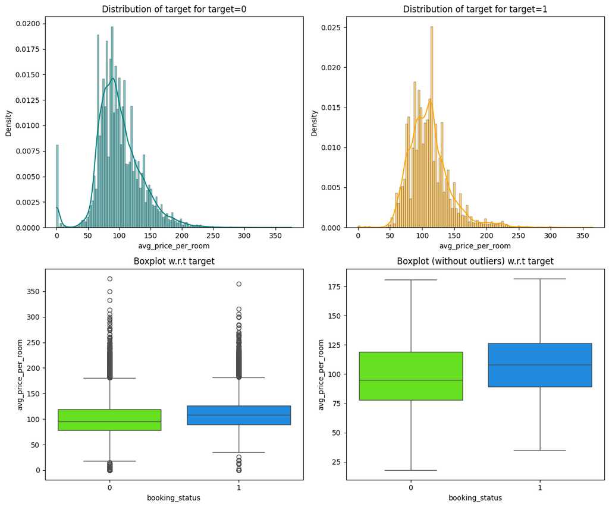

```python
distribution_plot_wrt_target(df, "avg_price_per_room", "booking_status")
```

**Observations**

#### **`Lead time and booking status`**

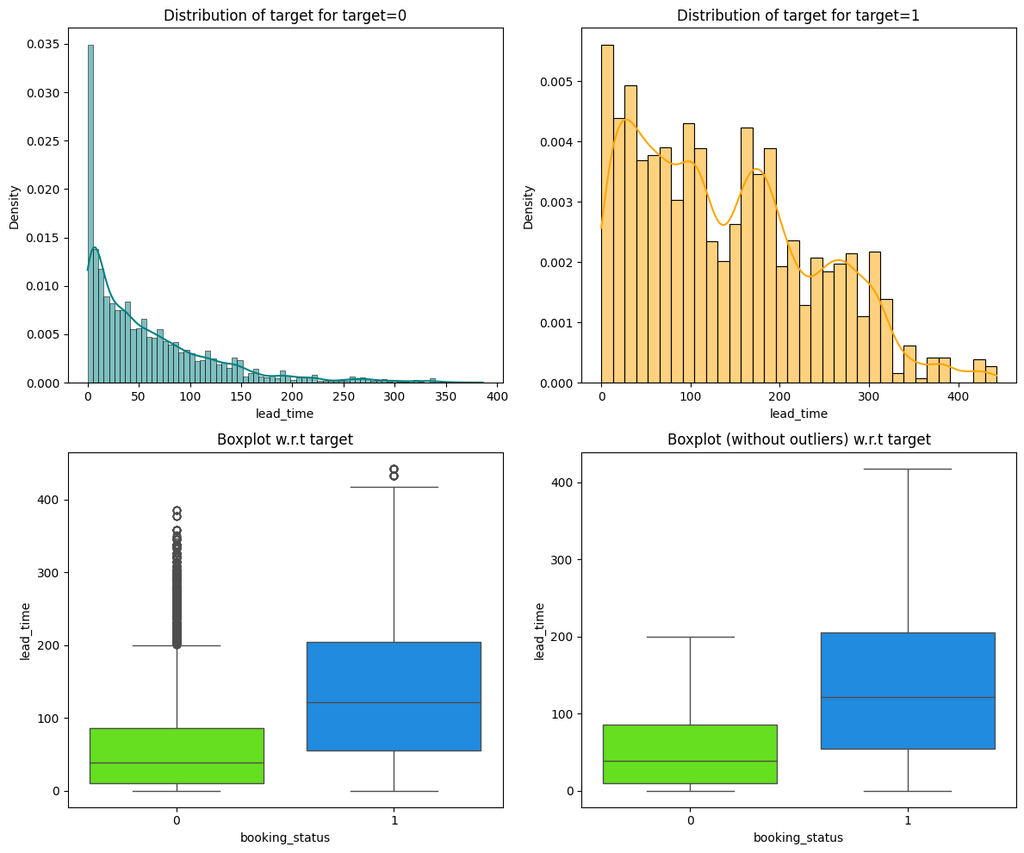

```python
distribution_plot_wrt_target(df, "lead_time", "booking_status")
```

**Observations**

#### **`Family members and booking status`**

```python
#Creating another DF for this analysis.
f_df = df[(df["no_of_children"] >= 0) & (df["no_of_adults"] > 1)]
f_df.shape
```

```
(28441, 18)
```

```python
f_df["no_of_family_members"] = (
    f_df["no_of_adults"] + f_df["no_of_children"]
)
```

```
booking_status            0     1    All
no_of_family_members
All                   18456  9985  28441
2                     15506  8213  23719
3                      2425  1368   3793
4                       514   398    912
5                        11     6     17
------------------------------------------------------------------------------------------------------------------------
```

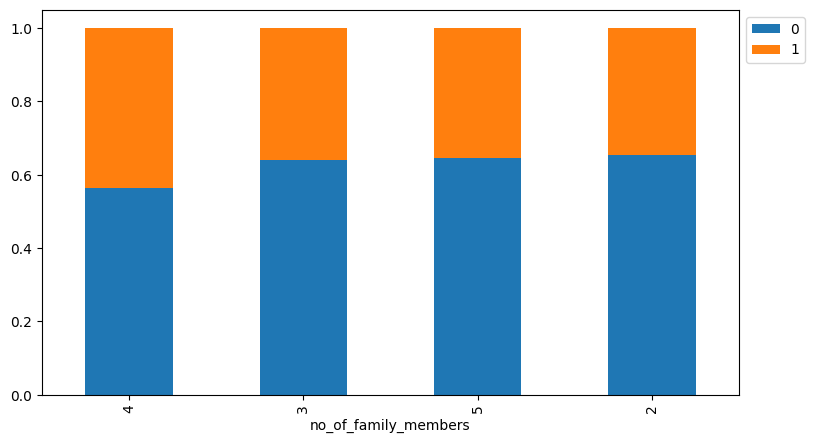

```python
stacked_barplot(f_df, "no_of_family_members", "booking_status")
```

**Observations**

```python
st_df = df[(df["no_of_week_nights"] >= 0) & (df["no_of_weekend_nights"] > 1)]
st_df.shape
```

```
(9408, 18)
```

```python
st_df["total_days"] = (
    st_df["no_of_week_nights"] + st_df["no_of_weekend_nights"]
)
```

```
booking_status     0     1   All
total_days
All             6048  3360  9408
3               1621   845  2466
4               1595   698  2293
5               1106   482  1588
7                590   383   973
6                385   333   718
2                488   299   787
8                100    79   179
10                51    58   109
9                 58    53   111
14                 5    27    32
15                 5    26    31
13                 3    15    18
12                 9    15    24
11                24    15    39
20                 3     8    11
16                 1     5     6
19                 1     5     6
17                 1     4     5
18                 0     3     3
21                 1     3     4
22                 0     2     2
23                 1     1     2
24                 0     1     1
------------------------------------------------------------------------------------------------------------------------
```

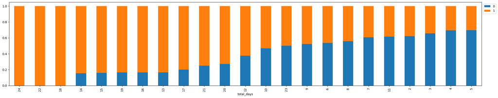

```python
stacked_barplot(st_df, "total_days", "booking_status")
```

**Observations**

#### **`Repeating guests and booking status`**

```
booking_status      0      1    All
repeated_guest
All             24390  11885  36275
0               23476  11869  35345
1                 914     16    930
------------------------------------------------------------------------------------------------------------------------
```

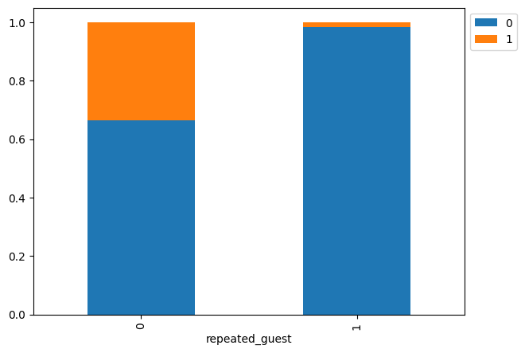

```python
stacked_barplot(df, "repeated_guest", "booking_status")
```

**Observations**

- The majority of guests that repeat their stay do not cancel their reservation. Data shows good fidelity among those that have visited the hotels before.

#### **`Months and booking status`**

```
booking_status      0      1    All
arrival_month
All             24390  11885  36275
10               3437   1880   5317
9                3073   1538   4611
8                2325   1488   3813
7                1606   1314   2920
6                1912   1291   3203
4                1741    995   2736
5                1650    948   2598
11               2105    875   2980
3                1658    700   2358
2                1274    430   1704
12               2619    402   3021
1                 990     24   1014
------------------------------------------------------------------------------------------------------------------------
```

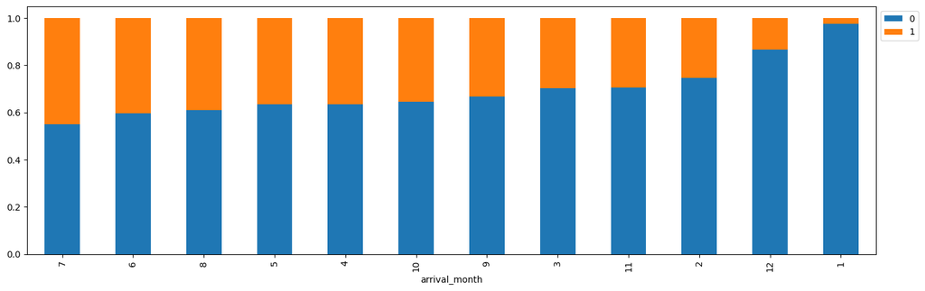

```python
stacked_barplot(df, "arrival_month", "booking_status")
```

**Observations**

- October and september are the months with more reservations and cancellations.
- As opposed, january shows much less reservations but just a few cancellations which demonstrates that those that come in the first month of the year do not cancell as many reservations.